# SI_370_Homework_3

### SI 370 - Homework #3: Applied Statistics

## Background

This homework assignment focuses on data from the [World Happiness Report](https://www.kaggle.com/unsdsn/world-happiness).

The World Happiness Report is a landmark survey of the state of global happiness. The first report was published in 2012, the second in 2013, the third in 2015, and the fourth in the 2016 Update. The World Happiness 2017, which ranks 155 countries by their happiness levels, was released at the United Nations at an event celebrating International Day of Happiness on March 20th. The report continues to gain global recognition as governments, organizations and civil society increasingly use happiness indicators to inform their policy-making decisions. Leading experts across fields – economics, psychology, survey analysis, national statistics, health, public policy and more – describe how measurements of well-being can be used effectively to assess the progress of nations. The reports review the state of happiness in the world today and show how the new science of happiness explains personal and national variations in happiness.

We will be using data from the 2016 report.

Your main task in this assignment is to explore the data *using the data manipulation, analysis, visualization, and applied statistical methods we covered in class* as well as those in the assigned readings.

**You should also feel free to ask questions on Piazza!**

Each question is worth the same number of points. Points will be allocated according to the rubric posted in Canvas, and corresponds roughly to the following guidelines:

- 90-100%: Question is correctly and completely answered. Answer consists of well-written code that conforms to [PEP 8](https://www.python.org/dev/peps/pep-0008/) guidelines and is accompanied by a written interpretation in a Markdown block. Written interpretation does not contain spelling, grammar or stylistic errors (see [Strunk & White](https://drive.google.com/file/d/1L0P7xJwjUGBvyb49mL3dw1Bt7hzRTiTl/view?usp=sharing) for detailed specifications). Minor problems, such as formatting, incorrect submissions, missing names, etc. will result in less than 100%.
- 75-85% : Answer is mostly complete and correct; two or fewer noticeable omissions or errors. Minor stylistic flaws, either in code or in written interpretation.
- 50-70%: Answer has significant omissions or errors; Noticeable departure from PEP-8 guildelines and/or moderate spelling, grammar, or style issues in written interpretations.
- 25-45%: Question is perfunctorily attempted. Substantial parts are missing or incorrect. **Remember to complete the interpretation sections -- focus on interpreting your results rather as well as explaining what you did.**
- 0 points: Question not attempted.

```python
import pandas as pd
import numpy as np
import matplotlib.pyplot as plt
import seaborn as sns
```

```python
happiness = pd.read_csv('https://raw.githubusercontent.com/umsi-data-science/data/main/world-happiness-2016.csv')
```

```python
happiness.shape
```

```
(157, 13)
```

```python
happiness.head(20)
```

|  | Country | Region | Happiness Rank | Happiness Score | Lower Confidence Interval | Upper Confidence Interval | Economy (GDP per Capita) | Family | Health (Life Expectancy) | Freedom | Trust (Government Corruption) | Generosity | Dystopia Residual |
| --- | --- | --- | --- | --- | --- | --- | --- | --- | --- | --- | --- | --- | --- |
| 0 | Denmark | Western Europe | 1 | 7.526 | 7.460 | 7.592 | 1.44178 | 1.16374 | 0.79504 | 0.57941 | 0.44453 | 0.36171 | 2.73939 |
| 1 | Switzerland | Western Europe | 2 | 7.509 | 7.428 | 7.590 | 1.52733 | 1.14524 | 0.86303 | 0.58557 | 0.41203 | 0.28083 | 2.69463 |
| 2 | Iceland | Western Europe | 3 | 7.501 | 7.333 | 7.669 | 1.42666 | 1.18326 | 0.86733 | 0.56624 | 0.14975 | 0.47678 | 2.83137 |
| 3 | Norway | Western Europe | 4 | 7.498 | 7.421 | 7.575 | 1.57744 | 1.12690 | 0.79579 | 0.59609 | 0.35776 | 0.37895 | 2.66465 |
| 4 | Finland | Western Europe | 5 | 7.413 | 7.351 | 7.475 | 1.40598 | 1.13464 | 0.81091 | 0.57104 | 0.41004 | 0.25492 | 2.82596 |
| 5 | Canada | North America | 6 | 7.404 | 7.335 | 7.473 | 1.44015 | 1.09610 | 0.82760 | 0.57370 | 0.31329 | 0.44834 | 2.70485 |
| 6 | Netherlands | Western Europe | 7 | 7.339 | 7.284 | 7.394 | 1.46468 | 1.02912 | 0.81231 | 0.55211 | 0.29927 | 0.47416 | 2.70749 |
| 7 | New Zealand | Australia and New Zealand | 8 | 7.334 | 7.264 | 7.404 | 1.36066 | 1.17278 | 0.83096 | 0.58147 | 0.41904 | 0.49401 | 2.47553 |
| 8 | Australia | Australia and New Zealand | 9 | 7.313 | 7.241 | 7.385 | 1.44443 | 1.10476 | 0.85120 | 0.56837 | 0.32331 | 0.47407 | 2.54650 |
| 9 | Sweden | Western Europe | 10 | 7.291 | 7.227 | 7.355 | 1.45181 | 1.08764 | 0.83121 | 0.58218 | 0.40867 | 0.38254 | 2.54734 |
| 10 | Israel | Middle East and Northern Africa | 11 | 7.267 | 7.199 | 7.335 | 1.33766 | 0.99537 | 0.84917 | 0.36432 | 0.08728 | 0.32288 | 3.31029 |
| 11 | Austria | Western Europe | 12 | 7.119 | 7.045 | 7.193 | 1.45038 | 1.08383 | 0.80565 | 0.54355 | 0.21348 | 0.32865 | 2.69343 |
| 12 | United States | North America | 13 | 7.104 | 7.020 | 7.188 | 1.50796 | 1.04782 | 0.77900 | 0.48163 | 0.14868 | 0.41077 | 2.72782 |
| 13 | Costa Rica | Latin America and Caribbean | 14 | 7.087 | 6.999 | 7.175 | 1.06879 | 1.02152 | 0.76146 | 0.55225 | 0.10547 | 0.22553 | 3.35168 |
| 14 | Puerto Rico | Latin America and Caribbean | 15 | 7.039 | 6.794 | 7.284 | 1.35943 | 1.08113 | 0.77758 | 0.46823 | 0.12275 | 0.22202 | 3.00760 |
| 15 | Germany | Western Europe | 16 | 6.994 | 6.930 | 7.058 | 1.44787 | 1.09774 | 0.81487 | 0.53466 | 0.28551 | 0.30452 | 2.50931 |
| 16 | Brazil | Latin America and Caribbean | 17 | 6.952 | 6.875 | 7.029 | 1.08754 | 1.03938 | 0.61415 | 0.40425 | 0.14166 | 0.15776 | 3.50733 |
| 17 | Belgium | Western Europe | 18 | 6.929 | 6.861 | 6.997 | 1.42539 | 1.05249 | 0.81959 | 0.51354 | 0.26248 | 0.24240 | 2.61355 |
| 18 | Ireland | Western Europe | 19 | 6.907 | 6.836 | 6.978 | 1.48341 | 1.16157 | 0.81455 | 0.54008 | 0.29754 | 0.44963 | 2.15988 |
| 19 | Luxembourg | Western Europe | 20 | 6.871 | 6.804 | 6.938 | 1.69752 | 1.03999 | 0.84542 | 0.54870 | 0.35329 | 0.27571 | 2.11055 |

## Answer the questions below.

For each question, you should

1. Write code that can help you answer the following questions, and
2. Explain your answers in plain English. You should use complete sentences that would be understood by an educated professional who is not necessarily a data scientist (like a product manager).

### Q1: What are the top 5 correlation coefficients among "Happiness Score", Economy, Family, Health, Freedom, Trust, and Generosity? Provide a visualization as well as a written statement of your findings. (5 points)

```python
narrowed = happiness[['Happiness Score','Economy (GDP per Capita)', 'Family', 'Health (Life Expectancy)', 'Freedom', 'Trust (Government Corruption)', 'Generosity']]
corr = narrowed.corr()
corr_pairs = corr.unstack()
sort_corr = pd.DataFrame(corr_pairs.sort_values())
sort_corr['absolute_corr'] = abs(sort_corr[0])
sort_corr = sort_corr.reset_index()
sort_corr = sort_corr.rename(columns={'level_0': 'var_1', 'level_1': 'var_2', 0:'Correlation'})
sort_corr = sort_corr.sort_values(by=['absolute_corr'], ascending=False)
sort_corr = sort_corr[sort_corr['absolute_corr'] != 1]
sort_corr = sort_corr.drop_duplicates(subset=['absolute_corr'])
sort_corr = sort_corr.rename(columns={'absolute_corr': 'Absolute Corr.'})
sort_corr.head()
```

|  | var_1 | var_2 | Correlation | Absolute Corr. |
| --- | --- | --- | --- | --- |
| 41 | Health (Life Expectancy) | Economy (GDP per Capita) | 0.837067 | 0.837067 |
| 39 | Happiness Score | Economy (GDP per Capita) | 0.790322 | 0.790322 |
| 36 | Health (Life Expectancy) | Happiness Score | 0.765384 | 0.765384 |
| 35 | Happiness Score | Family | 0.739252 | 0.739252 |
| 33 | Economy (GDP per Capita) | Family | 0.669540 | 0.669540 |

From the first display we can see that Health (Life Expectancy) and Economy (GDP per Capita) has the highest correlation followed by; Happiness Score and Economy (GDP per Capita), Health (Life Expectancy) and Happiness Score, Happiness Score and Family, and lastly Economy (GDP per Capita) and Family. We know that since these are the top five correlations found in the narrowed down dataset there is a strong relationship between these variables.

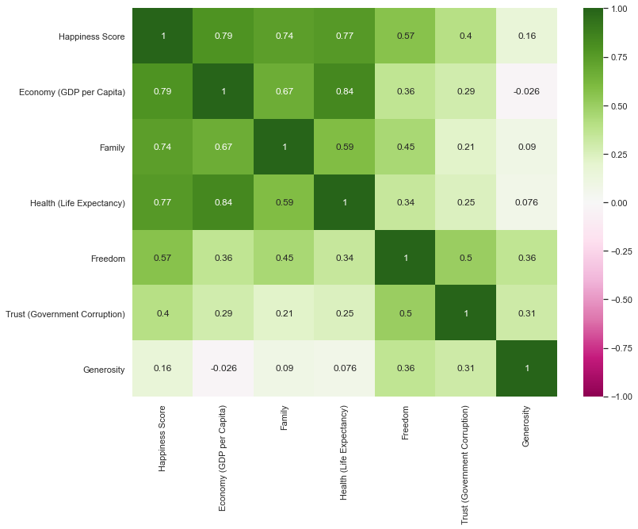

```python
sns.set(rc={'figure.figsize':(12,9)})
sns.heatmap(data=narrowed.corr(), cmap="PiYG" ,annot = True,vmax=1.0,vmin=-1.0)
```

This heatmap helps creates a visual of these correlations. Strong relations between two variables are shown in darker green colors. In this visual it is easier to see economy and happiness score has a higher ratio than freedom and generosity for example. I also choose this color scheme to show any negative correlations, although this is not very evident in this set of data, we can see that economy and generosity has a very low negative correlation. This is not a strong relation at all but in general we know that with negative correlations as one variable increases the other decreases.

### Q2: Describe, using plots, the relationships between the following variables: (5 points)

1. Happiness vs. Family
2. Happiness vs. Economy
3. Happiness vs. Health
4. Happiness vs. Freedom
5. Happiness vs. Trust
6. Happiness vs. Generosity

You have, at this point, a wide variety of visualizations that you know how to generate. Choose wisely!

```python
import warnings
warnings.filterwarnings("ignore")
```

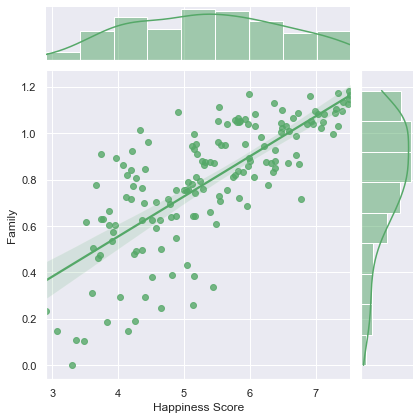

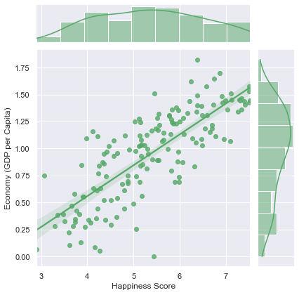

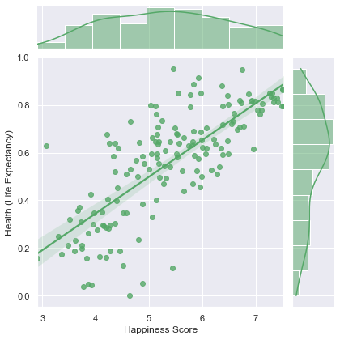

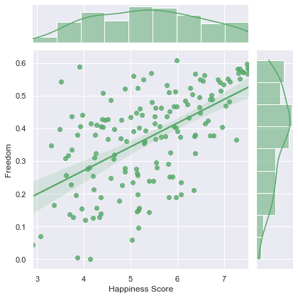

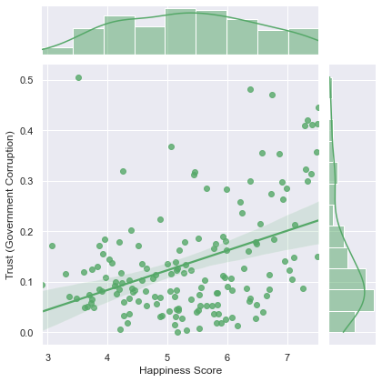

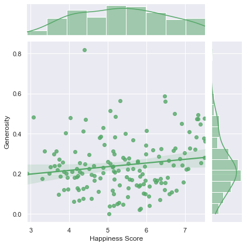

```python
sns.set(rc={'figure.figsize':(4,3)})

#list of the variables I want to plot against happiness
relations = ['Family','Economy (GDP per Capita)','Health (Life Expectancy)',
             'Freedom','Trust (Government Corruption)','Generosity']

for x in relations:
    sns.jointplot("Happiness Score", x, data=happiness, kind='reg', color='g')
```

- We can see that as family contributes more to the happiness scores the scores tend to increase as well.
- For economy we see a steeper slope where there is a positive relationship as well. Therefore as economy increase so does happiness score.
- We see a similar trend for health, where a postivie relationship is displayed.
- The relationship between freedom and happiness scores tends to be a little different. Although the regression line is postive there appears to be a large amount of data scattered far from the line. This infers that there is not a very strong relation between these two variables.
- Trust and happiness seem to also have a week, but still positive, relationship. There appears to be several high outliers and not an even distribution above and below the regression line.
- Lastly we have generosity and happiness showing barely any relation. The regression line indicates a very small slope, indicating that there is not much correlation between generosity and happiness scores.

### Q3: Does there appear to be an interaction between region and happiness quartile? (5 points)

Create a new variable that represents which quartile each country's happiness score is in. For example, the first 39 or 40 countries are in the 4th happiness quartile (it's up to you to decide exactly how to divide the countries into happiness quartiles).

(Hint: contingency tables, mosaic plots, and chi-square may be useful here).

```python
#creates a new column that sorts the rows into quartiles
def Quartile(row):

    if row.name <= 39:
        return 'Q1'
    elif row.name  <= 78:
        return 'Q2'
    elif row.name  <= 117:
        return 'Q3'
    else:
        return 'Q4'

happiness['Quartile'] = happiness.apply (lambda row: Quartile(row), axis=1)
happiness.head()
```

|  | Country | Region | Happiness Rank | Happiness Score | Lower Confidence Interval | Upper Confidence Interval | Economy (GDP per Capita) | Family | Health (Life Expectancy) | Freedom | Trust (Government Corruption) | Generosity | Dystopia Residual | Quartile |
| --- | --- | --- | --- | --- | --- | --- | --- | --- | --- | --- | --- | --- | --- | --- |
| 0 | Denmark | Western Europe | 1 | 7.526 | 7.460 | 7.592 | 1.44178 | 1.16374 | 0.79504 | 0.57941 | 0.44453 | 0.36171 | 2.73939 | Q1 |
| 1 | Switzerland | Western Europe | 2 | 7.509 | 7.428 | 7.590 | 1.52733 | 1.14524 | 0.86303 | 0.58557 | 0.41203 | 0.28083 | 2.69463 | Q1 |
| 2 | Iceland | Western Europe | 3 | 7.501 | 7.333 | 7.669 | 1.42666 | 1.18326 | 0.86733 | 0.56624 | 0.14975 | 0.47678 | 2.83137 | Q1 |
| 3 | Norway | Western Europe | 4 | 7.498 | 7.421 | 7.575 | 1.57744 | 1.12690 | 0.79579 | 0.59609 | 0.35776 | 0.37895 | 2.66465 | Q1 |
| 4 | Finland | Western Europe | 5 | 7.413 | 7.351 | 7.475 | 1.40598 | 1.13464 | 0.81091 | 0.57104 | 0.41004 | 0.25492 | 2.82596 | Q1 |

```python
data_crosstab = pd.crosstab(happiness['Region'],
                            happiness['Quartile'],
                              margins = False, normalize=False)
data_crosstab
```

| Quartile Region | Q1 | Q2 | Q3 | Q4 |
| --- | --- | --- | --- | --- |
| Australia and New Zealand | 2 | 0 | 0 | 0 |
| Central and Eastern Europe | 1 | 15 | 9 | 4 |
| Eastern Asia | 1 | 3 | 2 | 0 |
| Latin America and Caribbean | 11 | 10 | 2 | 1 |
| Middle East and Northern Africa | 5 | 4 | 7 | 3 |
| North America | 2 | 0 | 0 | 0 |
| Southeastern Asia | 2 | 2 | 3 | 2 |
| Southern Asia | 0 | 0 | 6 | 1 |
| Sub-Saharan Africa | 0 | 2 | 8 | 28 |
| Western Europe | 16 | 3 | 2 | 0 |

```python
from statsmodels.graphics.mosaicplot import mosaic
```

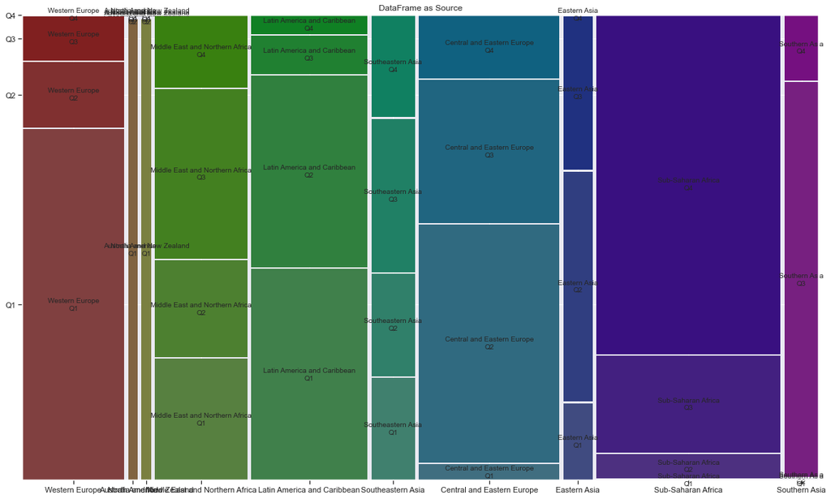

```python
plt.rcParams["figure.figsize"]=(20,12)
mosaic(happiness, ['Region', 'Quartile'], title='DataFrame as Source')
plt.show()
```

```python
from scipy.stats import chi2_contingency
chi2, p, dof, ex = chi2_contingency(data_crosstab)
print("chi2 = ", chi2)
print("p-val = ", p)
print("degree of freedom = ",dof)
print("Expected:")
pd.DataFrame(ex, index=data_crosstab.index, columns= data_crosstab.columns)
```

```
chi2 =  142.3798510538245
p-val =  1.2219368231534683e-17
degree of freedom =  27
Expected:
```

| Quartile Region | Q1 | Q2 | Q3 | Q4 |
| --- | --- | --- | --- | --- |
| Australia and New Zealand | 0.509554 | 0.496815 | 0.496815 | 0.496815 |
| Central and Eastern Europe | 7.388535 | 7.203822 | 7.203822 | 7.203822 |
| Eastern Asia | 1.528662 | 1.490446 | 1.490446 | 1.490446 |
| Latin America and Caribbean | 6.114650 | 5.961783 | 5.961783 | 5.961783 |
| Middle East and Northern Africa | 4.840764 | 4.719745 | 4.719745 | 4.719745 |
| North America | 0.509554 | 0.496815 | 0.496815 | 0.496815 |
| Southeastern Asia | 2.292994 | 2.235669 | 2.235669 | 2.235669 |
| Southern Asia | 1.783439 | 1.738854 | 1.738854 | 1.738854 |
| Sub-Saharan Africa | 9.681529 | 9.439490 | 9.439490 | 9.439490 |
| Western Europe | 5.350318 | 5.216561 | 5.216561 | 5.216561 |

### Q4: Use a linear regression to model the relationship between Happiness Score and Family. (5 points)

What does this tell you about the relationship?

You may wish to include a visualization.

```python
import statsmodels.api as sm
import statsmodels.formula.api as smf
```

```python
reg_model = smf.ols("Q('Family') ~ Q('Happiness Score')", data=happiness).fit()
reg_model.summary()
```

OLS Regression Results

| Dep. Variable: | Q('Family') | R-squared: | 0.546 |
| --- | --- | --- | --- |
| Model: | OLS | Adj. R-squared: | 0.544 |
| Method: | Least Squares | F-statistic: | 186.8 |
| Date: | Wed, 13 Oct 2021 | Prob (F-statistic): | 2.09e-28 |
| Time: | 20:55:58 | Log-Likelihood: | 47.294 |
| No. Observations: | 157 | AIC: | -90.59 |
| Df Residuals: | 155 | BIC: | -84.48 |
| Df Model: | 1 |  |  |
| Covariance Type: | nonrobust |  |  |

|  | coef | std err | t | P>\|t\| | [0.025 | 0.975] |
| --- | --- | --- | --- | --- | --- | --- |
| Intercept | -0.1359 | 0.070 | -1.954 | 0.052 | -0.273 | 0.001 |
| Q('Happiness Score') | 0.1727 | 0.013 | 13.667 | 0.000 | 0.148 | 0.198 |

| Omnibus: | 5.348 | Durbin-Watson: | 2.022 |
| --- | --- | --- | --- |
| Prob(Omnibus): | 0.069 | Jarque-Bera (JB): | 4.887 |
| Skew: | -0.403 | Prob(JB): | 0.0869 |
| Kurtosis: | 3.311 | Cond. No. | 27.4 |

Notes:  
[1] Standard Errors assume that the covariance matrix of the errors is correctly specified.

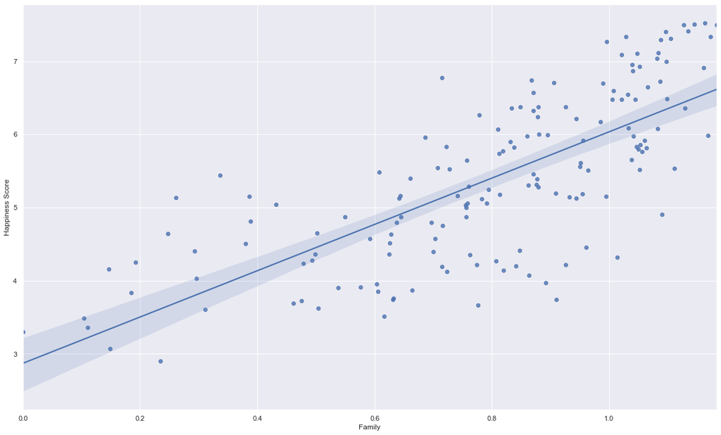

```python
# plt.scatter(happiness,happiness['Family'])
# line = 3.1645*happiness['Happiness Score'] + 2.8708
# fig = plt.plot(x, line, lw =3, label = "regression line")
sns.regplot(x="Family",
            y="Happiness Score",
            data=happiness);
```

### Q5: Do happiness scores vary significantly between regions? Which region has the highest mean happiness score? (5 points)

You may wish to include a visualization. Hint: ANOVA might help here.

```python
from statsmodels.formula.api import ols
```

```python
#made another column because the ANOVA method was not allowing for a two worded column to be passed through
happiness['Happiness'] = happiness['Happiness Score']
# happiness.head()

regional_hap = ols('Happiness ~ Region', data=happiness).fit()
table = sm.stats.anova_lm(regional_hap, typ=2) # Type 2 ANOVA DataFrame
table
```

|  | sum_sq | df | F | PR(>F) |
| --- | --- | --- | --- | --- |
| Region | 126.691462 | 9.0 | 26.999543 | 4.573860e-27 |
| Residual | 76.641811 | 147.0 | NaN | NaN |

[output not shown]

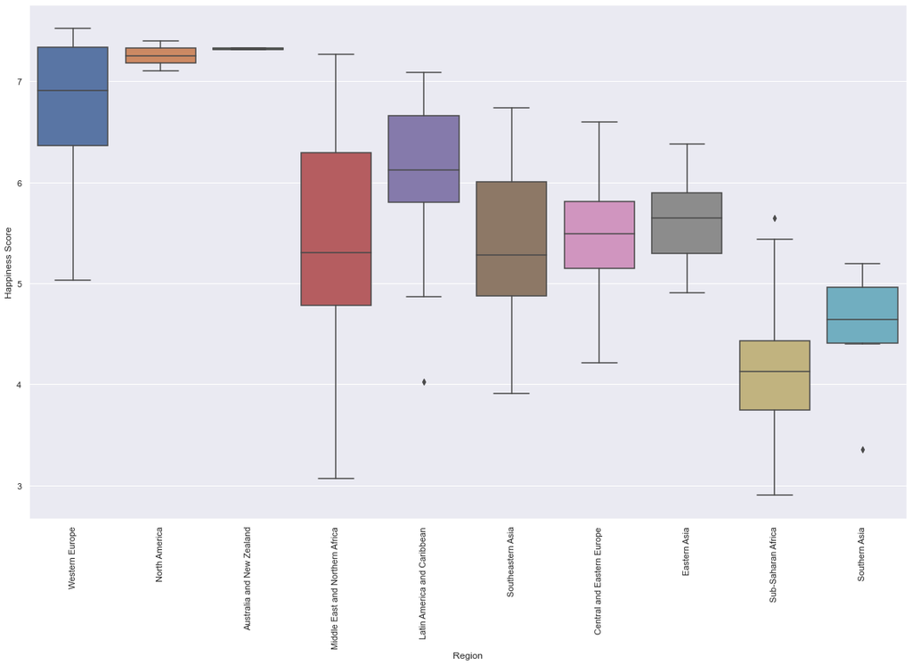

```python
import matplotlib.pyplot as plt
sns.boxplot("Region",y="Happiness Score",data=happiness)
plt.xticks(rotation=90)
```

```python
most_happy = happiness.groupby(['Region']).mean().sort_values(['Happiness Score'], ascending = False).reset_index()
most_happy.head(1)
```

|  | Region | Happiness Rank | Happiness Score | Lower Confidence Interval | Upper Confidence Interval | Economy (GDP per Capita) | Family | Health (Life Expectancy) | Freedom | Trust (Government Corruption) | Generosity | Dystopia Residual | Happiness |
| --- | --- | --- | --- | --- | --- | --- | --- | --- | --- | --- | --- | --- | --- |
| 0 | Australia and New Zealand | 8.5 | 7.3235 | 7.2525 | 7.3945 | 1.402545 | 1.13877 | 0.84108 | 0.57492 | 0.371175 | 0.48404 | 2.511015 | 7.3235 |

From the anova test we can see that the p-value is very low therefore we reject the null hypothesis. By rejecting we infer that happiness scores vary throughout regions. As seen in the box plot as well most regions have a small range of scores within the 25%-75% portions. The box plot along with the lat block of code also helps us see that Australia and New Zealand have the highest mean happiness score of 7.3235.

## Please submit your completed notebook in .HTML format via Canvas